# Task5

### 2.4. Handling “Corrupted” Data (`NA`)

```r
### 2.4. Handling "Corrupted" Data (NA) — Bernolákovo

# Copy the dataset
df_corrupted <- bern_data

# Introduce 3 NA values
df_corrupted[2, "dist_km"]        <- NA
df_corrupted[5, "pop"]            <- NA
df_corrupted[3, "has_playground"] <- NA

# Total number of NA values
sum(is.na(df_corrupted))

# Number of NA values per column
colSums(is.na(df_corrupted))

# Mean of a numeric column with and without NA removal
mean(df_corrupted$pop)
mean(df_corrupted$pop, na.rm = TRUE)

# Create a clean version without missing values
df_clean <- na.omit(df_corrupted)
df_clean
```

[output not shown]

### 2.5. Bonus Challenge: `which()`

```r
# index of max in a numeric column
 idx_max_pop <- which.max(bern_data$pop)
bern_data[idx_max_pop, ]
```

```
# A tibble: 1 × 6
  district   pop has_playground zone  dist_km priority
  <chr>    <dbl> <lgl>          <chr>   <dbl> <chr>
1 Centrum   1800 TRUE           mixed     0.2 medium
```

```r
# index of min in another numeric column

idx_min_dist <- which.min(bern_data$dist_km)
bern_data[idx_min_dist, ]
```

```
# A tibble: 1 × 6
  district   pop has_playground zone  dist_km priority
  <chr>    <dbl> <lgl>          <chr>   <dbl> <chr>
1 Centrum   1800 TRUE           mixed     0.2 medium
```

Your “mini-universe” in Tasks 1 & 2 was a simulation. Now, it’s time to connect it to the real world.

Your mission is to find a real dataset that expands on your theme, import it into R, and explore it using the dplyr package.

3.1. The Quest: Find Your Data Find one simple, real-world dataset that fits your theme.

Where to look: Kaggle, TidyTuesday, data.gov, or other public data portals.

Format: Any format you are able to read. For simplicity it is proposed to use textual (csv, txt) or Excel format.

Requirements:

At least 50 rows.

At least 4 columns.

A mix of numeric and character/factor data.

Action:

Download the data file and place it in your R project directory.

In your task file add a line with the link to the data source (e.g., Data from: https://…).

### 3.2. The Import: Load Your Data

Install tidyverse: If you haven’t, run install.packages(“tidyverse”) in your console (just once).

Load libraries: At the top of your script, add library(dplyr) and library(readr) (library(readxl) in case of Excel file format).

Read the data: Use read_csv() (or read_excel()) to load your dataset into a new data frame.

```r
# Load libraries
library(dplyr)
library(readr)

# Load data
bern_data <- read_csv("bernolakovo_df.csv")
# Quick inspection
glimpse(bern_data)
```

```
Rows: 6
Columns: 6
$ district       <chr> "Centrum", "Juhozápad", "Sever", "Východ", "Záhrady", "…
$ pop            <dbl> 1800, 1200, 950, 1100, 700, 450
$ has_playground <lgl> TRUE, TRUE, FALSE, TRUE, FALSE, TRUE
$ zone           <chr> "mixed", "residential", "residential", "industrial", "r…
$ dist_km        <dbl> 0.2, 1.4, 1.1, 2.3, 1.8, 2.7
$ priority       <chr> "medium", "medium", "low", "medium", "low", "low"
```

```r
head(bern_data)
```

```
# A tibble: 6 × 6
  district     pop has_playground zone         dist_km priority
  <chr>      <dbl> <lgl>          <chr>          <dbl> <chr>
1 Centrum     1800 TRUE           mixed            0.2 medium
2 Juhozápad   1200 TRUE           residential      1.4 medium
3 Sever        950 FALSE          residential      1.1 low
4 Východ      1100 TRUE           industrial       2.3 medium
5 Záhrady      700 FALSE          residential      1.8 low
6 Pri Jazere   450 TRUE           recreational     2.7 low
```

```r
summary(bern_data)
```

```
   district              pop         has_playground      zone
 Length:6           Min.   : 450.0   Mode :logical   Length:6
 Class :character   1st Qu.: 762.5   FALSE:2         Class :character
 Mode  :character   Median :1025.0   TRUE :4         Mode  :character
                    Mean   :1033.3
                    3rd Qu.:1175.0
                    Max.   :1800.0
    dist_km        priority
 Min.   :0.200   Length:6
 1st Qu.:1.175   Class :character
 Median :1.600   Mode  :character
 Mean   :1.583
 3rd Qu.:2.175
 Max.   :2.700
```

You must write the question in plain English (as a comment), followed by the dplyr code that answers it.

You must use each of the following dplyr “verbs” at least once:

select() - To pick specific columns.

filter() - To subset rows based on a condition.

arrange() - To sort your results (e.g., with desc()).

mutate() - To create a new column.

group_by() and summarise() - To get summary statistics (like mean(), n(), max(), etc.).

Your 5 Questions (example):

**Question 1**: Which 5 cities have the highest population?

```r
bern_data %>%
  select(district, population = pop) %>%
  arrange(desc(population)) %>%
  head(5)
```

```
# A tibble: 5 × 2
  district  population
  <chr>          <dbl>
1 Centrum         1800
2 Juhozápad       1200
3 Východ          1100
4 Sever            950
5 Záhrady          700
```

```r
bern_data %>%
  group_by(zone) %>%
  summarise(avg_population = mean(pop, na.rm = TRUE), n = n()) %>%
  arrange(desc(avg_population))
```

```
# A tibble: 4 × 3
  zone         avg_population     n
  <chr>                 <dbl> <int>
1 mixed                  1800     1
2 industrial             1100     1
3 residential             950     3
4 recreational            450     1
```

```r
bern_data %>%
  filter(!is.na(dist_km), dist_km > 0) %>%
  mutate(density = pop / dist_km) %>%
  select(district, zone, density) %>%
  arrange(desc(density))
```

```
# A tibble: 6 × 3
  district   zone         density
  <chr>      <chr>          <dbl>
1 Centrum    mixed          9000
2 Sever      residential     864.
3 Juhozápad  residential     857.
4 Východ     industrial      478.
5 Záhrady    residential     389.
6 Pri Jazere recreational    167.
```

```r
bern_data %>%
  filter(pop > 1000) %>%
  select(district, pop, zone) %>%
  arrange(desc(pop))
```

```
# A tibble: 3 × 3
  district    pop zone
  <chr>     <dbl> <chr>
1 Centrum    1800 mixed
2 Juhozápad  1200 residential
3 Východ     1100 industrial
```

```r
bern_data %>%
  group_by(zone, has_playground) %>%
  summarise(count = n(), .groups = "drop") %>%
  arrange(zone, desc(has_playground))
```

```
# A tibble: 5 × 3
  zone         has_playground count
  <chr>        <lgl>          <int>
1 industrial   TRUE               1
2 mixed        TRUE               1
3 recreational TRUE               1
4 residential  TRUE               1
5 residential  FALSE              2
```

## Task 4. Building a “Toolkit” for Your Universe (Functions)

In Task 3, you performed a “one-off” analysis of your new dataset. In the real world, you’ll want to run that analysis again and again.

The best way to do this is by capturing your code inside **functions**. A function is a reusable “tool” that you build to perform a specific job.

Your mission is to build a “toolkit” of functions that can analyse the dataset you found in Task 3.

**Important:** You must use the **same dataset** and theme you used in Task 3.

### 4.1. The “Greeting” Function (A Simple Start)

Let’s start with the basics. Write a simple function that prints a welcome message for your “universe”.

1. **Write the function:** It should take at least one argument (e.g., `your_name` or `universe_name`).
2. **Inside the function:** Use `print()` or `cat()` to display a message.
3. **Call the function:** After you define the function, you must call it to see the result.

```r
welcome_to_my_universe <- function(your_name, universe_name) {
  cat("--------------------------------\n")
  cat("Analysis Toolkit for:", universe_name, "\n")
  cat("Report prepared by:", your_name, "\n")
  cat("--------------------------------\n\n")
}

# Call the function
welcome_to_my_universe(
  your_name = "Yevheniia",
  universe_name = "Bernolákovo Mini-Universe"
)
```

```
--------------------------------
Analysis Toolkit for: Bernolákovo Mini-Universe
Report prepared by: Yevheniia
--------------------------------
```

### 4.2. The “Loading” Function (A Good Practice)

In Task 3, you wrote code to load and inspect your data. Let’s turn that into a function. This is a very common and useful practice.

1. **Write the function:** Name it `load_and_inspect`. It should take one argument: `file_path`.
2. **Inside the function:**
- Load the `readr` and `dplyr` libraries.
- Use `read_csv(file_path)` to load the data.
- Print a message (e.g., “Data loaded successfully.”).
- Print the `glimpse()` of the data.
- Print the `head()` of the data.
- **Return** the data frame (use the `return()` command).
3. **Call the function:**

```r
library(readr)
library(dplyr)

load_and_inspect <- function(file_path) {

  data <- read_csv(file_path, show_col_types = FALSE)

  cat("--- Data loaded from:", file_path, "---\n\n")

  cat("Data structure (glimpse):\n")
  print(glimpse(data))

  cat("\n--- First 6 rows ---\n")
  print(head(data))

  return(data)
}

# Load your dataset
bern_data <- load_and_inspect("bernolakovo_df.csv")
```

```
--- Data loaded from: bernolakovo_df.csv ---

Data structure (glimpse):
Rows: 6
Columns: 6
$ district       <chr> "Centrum", "Juhozápad", "Sever", "Východ", "Záhrady", "…
$ pop            <dbl> 1800, 1200, 950, 1100, 700, 450
$ has_playground <lgl> TRUE, TRUE, FALSE, TRUE, FALSE, TRUE
$ zone           <chr> "mixed", "residential", "residential", "industrial", "r…
$ dist_km        <dbl> 0.2, 1.4, 1.1, 2.3, 1.8, 2.7
$ priority       <chr> "medium", "medium", "low", "medium", "low", "low"
# A tibble: 6 × 6
  district     pop has_playground zone         dist_km priority
  <chr>      <dbl> <lgl>          <chr>          <dbl> <chr>
1 Centrum     1800 TRUE           mixed            0.2 medium
2 Juhozápad   1200 TRUE           residential      1.4 medium
3 Sever        950 FALSE          residential      1.1 low
4 Východ      1100 TRUE           industrial       2.3 medium
5 Záhrady      700 FALSE          residential      1.8 low
6 Pri Jazere   450 TRUE           recreational     2.7 low

--- First 6 rows ---
# A tibble: 6 × 6
  district     pop has_playground zone         dist_km priority
  <chr>      <dbl> <lgl>          <chr>          <dbl> <chr>
1 Centrum     1800 TRUE           mixed            0.2 medium
2 Juhozápad   1200 TRUE           residential      1.4 medium
3 Sever        950 FALSE          residential      1.1 low
4 Východ      1100 TRUE           industrial       2.3 medium
5 Záhrady      700 FALSE          residential      1.8 low
6 Pri Jazere   450 TRUE           recreational     2.7 low
```

### 4.3. The “Query” Function (The Core of the Task)

```r
bern_data %>%
  filter(!is.na(dist_km), dist_km > 0) %>%
  mutate(density = pop / dist_km) %>%
  select(district, zone, density) %>%
  arrange(desc(density))
```

```
# A tibble: 6 × 3
  district   zone         density
  <chr>      <chr>          <dbl>
1 Centrum    mixed          9000
2 Sever      residential     864.
3 Juhozápad  residential     857.
4 Východ     industrial      478.
5 Záhrady    residential     389.
6 Pri Jazere recreational    167.
```

```r
filter_by_density <- function(data, min_density) {

  result <- data %>%
    filter(!is.na(dist_km), dist_km > 0) %>%
    mutate(density = pop / dist_km) %>%
    filter(density >= min_density) %>%
    select(district, zone, density) %>%
    arrange(desc(density))

  return(result)
}
```

```r
# Example call: districts with density >= 500
density_result <- filter_by_density(bern_data, min_density = 500)

print(density_result)
```

```
# A tibble: 3 × 3
  district  zone        density
  <chr>     <chr>         <dbl>
1 Centrum   mixed         9000
2 Sever     residential    864.
3 Juhozápad residential    857.
```

### 4.4. The “Reporting” Function

Let’s combine everything. Write a single function that calculates several key statistics for a specific **group** or **category** in your data.

1. **Write the function:** Name it `generate_report`. It should take `data` and a `category_name` as arguments (e.g., a specific city, planet type, or region).
2. **Inside the function**:
   - `filter()` your data for only the `category_name` provided.
   - Calculate 3-4 interesting summary statistics (e.g., `mean()`, `max()`, `min()`, `n()`).
   - Use `cat()` to print a nicely formatted “report” to the console.

**Example:**

```r
generate_report <- function(data, zone_name) {

  # 1. Filter for the selected zone
  zone_data <- data %>%
    filter(zone == zone_name)

  # If there are no matching rows
  if (nrow(zone_data) == 0) {
    cat("No records found for zone:", zone_name, "\n\n")
    return(invisible(NULL))
  }

  # 2. Calculate key statistics
  avg_population  <- mean(zone_data$pop, na.rm = TRUE)
  max_population  <- max(zone_data$pop, na.rm = TRUE)
  min_population  <- min(zone_data$pop, na.rm = TRUE)
  avg_distance    <- mean(zone_data$dist_km, na.rm = TRUE)
  count_records   <- nrow(zone_data)
  share_playground <- mean(zone_data$has_playground, na.rm = TRUE) * 100

  # 3. Print formatted report
  cat("----------------------------------------\n")
  cat("Report for zone:", zone_name, "\n")
  cat("----------------------------------------\n")
  cat("Number of districts:", count_records, "\n")
  cat("Average population:", round(avg_population, 1), "\n")
  cat("Maximum population:", max_population, "\n")
  cat("Minimum population:", min_population, "\n")
  cat("Average distance (km):", round(avg_distance, 2), "\n")
  cat("Playground availability (%):", round(share_playground, 1), "\n")
  cat("----------------------------------------\n\n")
}
```

```r
generate_report(bern_data, "residential")
```

```
----------------------------------------
Report for zone: residential
----------------------------------------
Number of districts: 3
Average population: 950
Maximum population: 1200
Minimum population: 700
Average distance (km): 1.43
Playground availability (%): 33.3
----------------------------------------
```

```r
generate_report(bern_data, "mixed")
```

```
----------------------------------------
Report for zone: mixed
----------------------------------------
Number of districts: 1
Average population: 1800
Maximum population: 1800
Minimum population: 1800
Average distance (km): 0.2
Playground availability (%): 100
----------------------------------------
```

## Task 5. Visualising Your Universe (Base R & ggplot2)

You have found your data (Task 3) and built tools to analyse it (Task 4). Now, you must present your findings to customers.

Your goal is to create four specific visualizations based on the real-world dataset you imported in Task 3.

**Prerequisites:**

- Use the dataset you found and cleaned in Task 3.
- Make sure `library(ggplot2)` is loaded.
- **Crucial:** Every plot must have a **Title**, **x-axis label**, and **y-axis label** that make sense for your specific theme.

```r
library(dplyr)
library(readr)
library(ggplot2)
```

### 5.1. The Quick Sketch (Base R Histogram)

Sometimes you need a quick look at the distribution of your data without loading heavy packages.

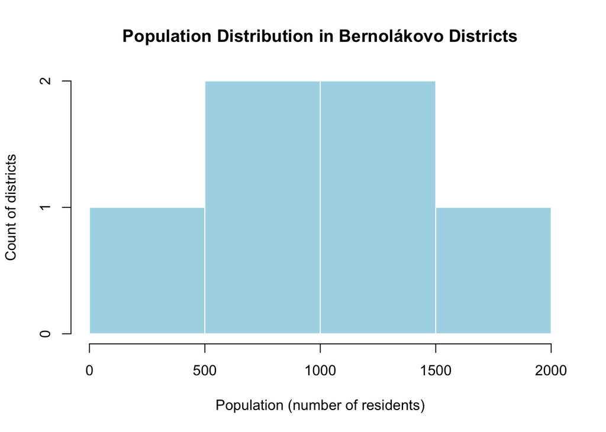

```r
hist(
  bern_data$pop,
  main = "Population Distribution in Bernolákovo Districts",
  xlab = "Population (number of residents)",
  ylab = "Count of districts",
  col  = "lightblue",
  border = "white"
)
```

### 5.2. The Relationship Map (ggplot2 Scatter Plot)

Now, let’s look for patterns using the industry-standard package, **ggplot2**.

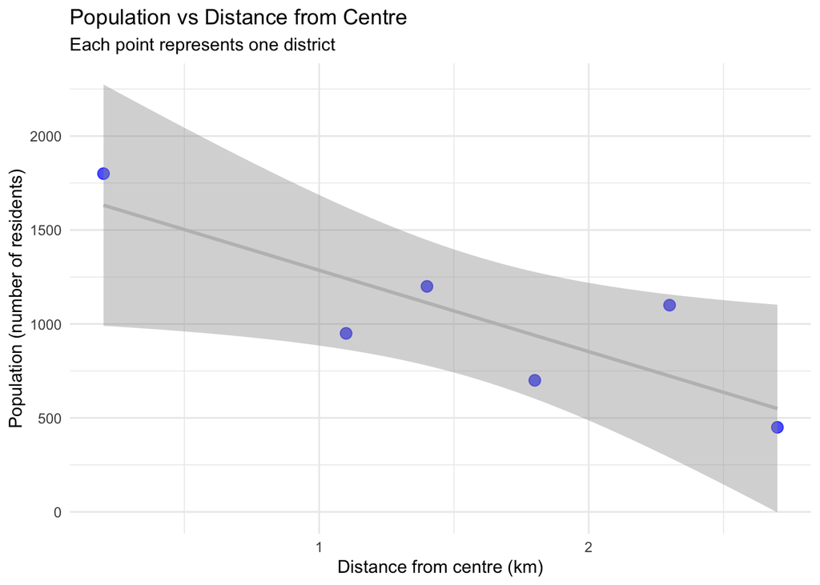

```r
population_distance_plot <- ggplot(
  data = bern_data,
  aes(x = dist_km, y = pop)
) +
  geom_point(alpha = 0.7, size = 3, colour = "blue") +
  geom_smooth(method = "lm", colour = "gray") +
  labs(
    title    = "Population vs Distance from Centre",
    subtitle = "Each point represents one district",
    x        = "Distance from centre (km)",
    y        = "Population (number of residents)"
  ) +
  theme_minimal()

population_distance_plot
```

### 5.3. The Comparison (ggplot2 Boxplot)

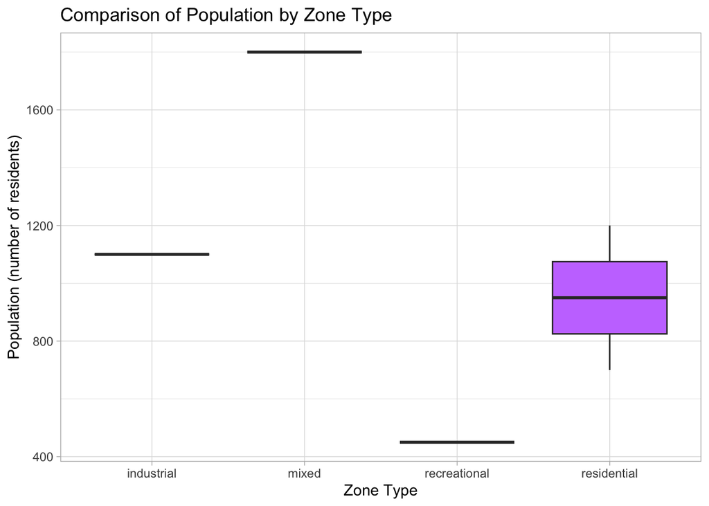

```r
ggplot(data = bern_data, aes(x = zone, y = pop, fill = zone)) +
  geom_boxplot() +
  labs(
    title = "Comparison of Population by Zone Type",
    x     = "Zone Type",
    y     = "Population (number of residents)"
  ) +
  theme_light() +
  theme(legend.position = "none")
```

### 5.4. The “Deep Dive” (Faceting or Custom)

The most powerful feature of `ggplot2` is faceting—creating small multiples of the same plot for different groups.

1. Create a plot (histogram, bar plot, or scatter plot).
2. Use `facet_wrap(~ your_category_variable)` to split the plot into a separate panel for each group in your data.
3. This is incredibly useful for comparing distinct groups (e.g., separate charts for each City or Year).

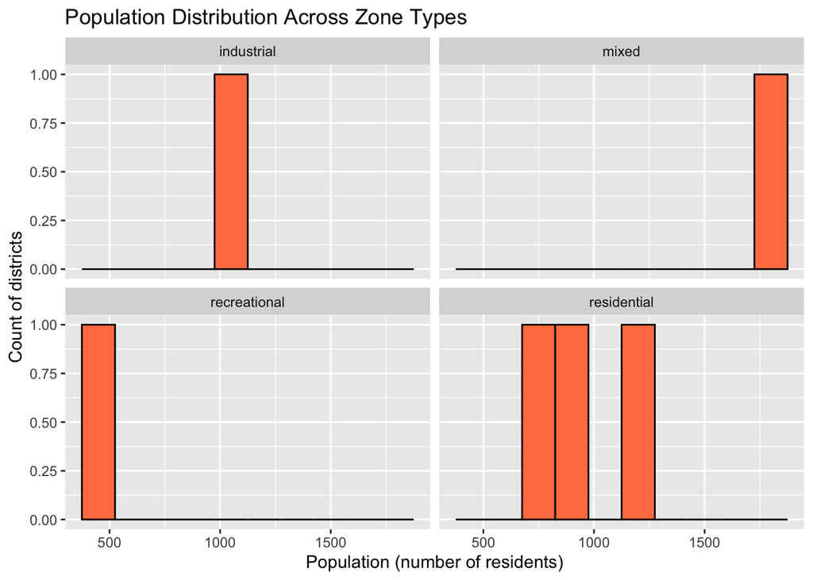

```r
ggplot(data = bern_data, aes(x = pop)) +
  geom_histogram(bins = 10, fill = "coral", color = "black") +
  facet_wrap(~ zone) +
  labs(
    title = "Population Distribution Across Zone Types",
    x     = "Population (number of residents)",
    y     = "Count of districts"
  )
```

### 5.5. Final Step: Exporting (Saving Your Work)

A plot is useless if you can’t put it in a report.

1. Choose your favourite plot from the exercises above.
2. Run the code to display it in R.
3. Immediately run the following command to save it to your project folder:

```r
ggsave(
  "my_universe_plot.png",
  plot   = population_distance_plot,
  width  = 8,
  height = 6
)
```